# THEM6: GSEA analysis

Peter Repiscak

# Brief description

Gene Set Enrichment Analysis of Them6 differential expression results from 4 conditions (AI_WT, AI_CTL, AI_KO1, AI_KO2) and following comparisons:

- KO1_vs_CTL
- KO2_vs_CTL
- KO1_vs_WT
- KO2_vs_WT

GSEA was perfomed in discovery mode (using gs_hallmark, gs_C2_kegg, gs_C2_reactome, gs_C5_GO(BP|CC|MF)) and supervised mode to assess lipid, sterol or cholesterol pathway down-regulation in THEM6_KO.

# Methods

```r
# importing only key functions that are actually used - not to polute namespace!
import::from(readr, read_csv)
import::from(magrittr, "%>%")
import::from(dplyr, mutate, select, filter, rename, arrange, desc, group_by, summarise, ungroup)  # dplyr_mutate = mutate
import::from(purrr, map)
import::from(future, plan, multisession, sequential)
import::from(furrr, furrr_options, future_map2)
import::from(ggplot2, .all=TRUE) # importing all as there is too many
#import::from(.from = DOSE, gseaScores)

# importing functions ----
#https://import.rticulate.org/articles/import.html#advanced-usage-1
# renv::install('bit64')
import::from(.from = here::here("scripts/utils.R"), "save_rds", "digest_match", "create_rnk_list", "gsea_function", "gseaPlotESprofile", "tableGrob2", "gsInfo", .character_only=TRUE)
import:::from(gseaScores, .from = DOSE)

# if there is an issue with clusterProfiler: "object 'get_fun_from_pkg' not found"
# downgrade "rvcheck":
# renv::install("rvcheck@0.1.8") rather than devtools::install_version("rvcheck", version = "0.1.8", repos = "http://cran.us.r-project.org")
# and re-install renv::install("bioc::clusterProfiler") rather than BiocManager::install("clusterProfiler")
```

# GSEA results

Results are generated in the results_dir. This folder contains complete results saved as .RData/.xlsx files and figures saved as .tiff.

## KO1_vs_CTL

Lipid genesets:

```r
DT::datatable(dplyr::select(KO1_vs_CTL_gsea_LIPIDS_results_df$LIPID, c("ID", "enrichmentScore", "NES", "pvalue", "p.adjust")) %>% dplyr::arrange(., pvalue),
              rownames = FALSE,
              options = list(pageLength = 10),
              caption = 'Table 1: KO1_vs_CTL - LIPIDS GSEA results.') %>%
  DT::formatRound(c('enrichmentScore', 'NES'), 2) %>%
  DT::formatRound(c('pvalue', 'p.adjust'), 4)
```

| ID | enrichmentScore | NES | pvalue | p.adjust |
| --- | --- | --- | --- | --- |
| GOBP_REGULATION_OF_LIPID_METABOLIC_PROCESS | -0.461764487114163 | -1.48382405907636 | 0.000945473960534805 | 0.0511243283736309 |
| GOBP_REGULATION_OF_LIPID_BIOSYNTHETIC_PROCESS | -0.507584828388473 | -1.54070085462769 | 0.00254067523330239 | 0.0511243283736309 |
| GOBP_NEUTRAL_LIPID_METABOLIC_PROCESS | -0.555990153951843 | -1.60359904156582 | 0.00275716077775455 | 0.0511243283736309 |
| GOBP_POSITIVE_REGULATION_OF_LIPID_METABOLIC_PROCESS | -0.545318684194266 | -1.58822993451279 | 0.00288024385203554 | 0.0511243283736309 |
| GOBP_REGULATION_OF_LIPID_LOCALIZATION | -0.517296501880089 | -1.51827606248212 | 0.00675131382101346 | 0.0885595446799943 |
| GOBP_INTESTINAL_LIPID_ABSORPTION | -0.817591620753346 | -1.61054861979594 | 0.0124853821283621 | 0.0885595446799943 |
| GOBP_NEUTRAL_LIPID_CATABOLIC_PROCESS | -0.64863323039646 | -1.58891148170607 | 0.0136562547155576 | 0.0885595446799943 |
| GOBP_REGULATION_OF_LIPID_TRANSPORT | -0.522867592175025 | -1.4915561893452 | 0.014138953611523 | 0.0885595446799943 |
| GOBP_PHOSPHOLIPID_HOMEOSTASIS | -0.786479385653304 | -1.60587036856867 | 0.0146289609556913 | 0.0885595446799943 |
| GOBP_GLYCEROLIPID_CATABOLIC_PROCESS | -0.574551570858368 | -1.53403587935707 | 0.015725578769057 | 0.0885595446799943 |

[output cut: 61 more lines]

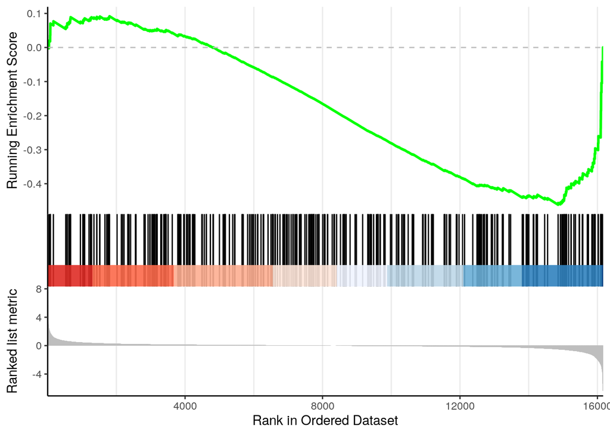

KO1_vs_CTL: GOBP_REGULATION_OF_LIPID_METABOLIC_PROCESS

```r
print(KO1_vs_CTL_LIPID_gseaplots$GOBP_REGULATION_OF_LIPID_METABOLIC_PROCESS)
```

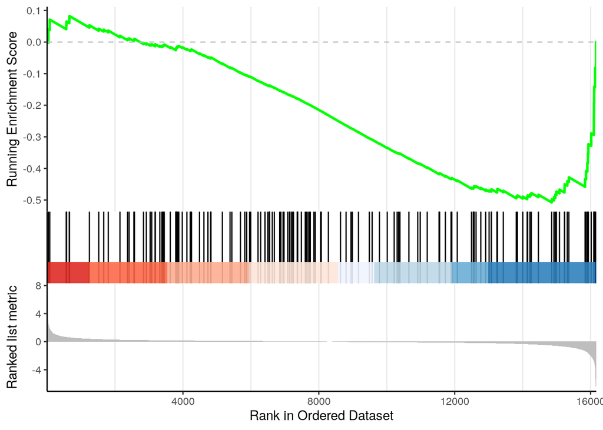

KO1_vs_CTL: GOBP_REGULATION_OF_LIPID_BIOSYNTHETIC_PROCESS

```r
print(KO1_vs_CTL_LIPID_gseaplots$GOBP_REGULATION_OF_LIPID_BIOSYNTHETIC_PROCESS)
```

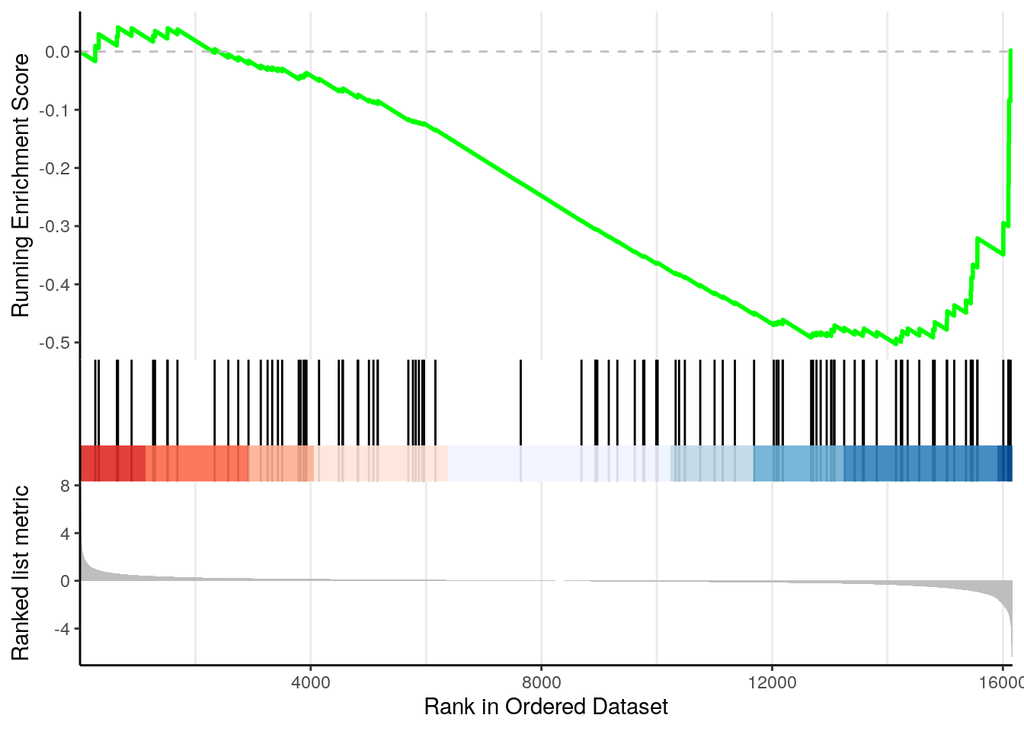

KO1_vs_CTL: GOBP_LIPID_HOMEOSTASIS

```r
print(KO1_vs_CTL_LIPID_gseaplots$GOBP_LIPID_HOMEOSTASIS)
```

Sterol genesets:

```r
DT::datatable(dplyr::select(KO1_vs_CTL_gsea_LIPIDS_results_df$STEROL, c("ID", "enrichmentScore", "NES", "pvalue", "p.adjust")) %>% dplyr::arrange(., pvalue),
              rownames = FALSE,
              options = list(pageLength = 10),
              caption = 'Table 1: KO1_vs_CTL - STEROLS GSEA results.') %>%
  DT::formatRound(c('enrichmentScore', 'NES'), 2) %>%
  DT::formatRound(c('pvalue', 'p.adjust'), 4)
```

| ID | enrichmentScore | NES | pvalue | p.adjust |
| --- | --- | --- | --- | --- |
| GOBP_STEROL_HOMEOSTASIS | -0.567042804537389 | -1.51109455496953 | 0.0205297263646396 | 0.234554495056295 |
| GOBP_REGULATION_OF_CHOLESTEROL_METABOLIC_PROCESS | -0.56861411440481 | -1.49824481135527 | 0.0246899468480311 | 0.234554495056295 |
| GOBP_STEROL_METABOLIC_PROCESS | -0.418388911700493 | -1.24746811532697 | 0.109959181629229 | 0.571309119414685 |
| GOBP_STEROL_TRANSPORT | -0.446608136214962 | -1.25453138137284 | 0.130937651299155 | 0.571309119414685 |
| GOBP_STEROL_BIOSYNTHETIC_PROCESS | -0.451406436878241 | -1.24215713610068 | 0.150344505109128 | 0.571309119414685 |
| GOBP_REVERSE_CHOLESTEROL_TRANSPORT | -0.621180801139217 | -1.24546036434936 | 0.226257363707563 | 0.663952921956773 |
| GOBP_REGULATION_OF_CHOLESTEROL_BIOSYNTHETIC_PROCESS | -0.449337746845595 | -1.148071132572 | 0.27277654883462 | 0.663952921956773 |
| GOBP_CHOLESTEROL_STORAGE | -0.5372068378153 | -1.15718030199199 | 0.301742331288344 | 0.663952921956773 |
| GOBP_POSITIVE_REGULATION_OF_STEROL_TRANSPORT | -0.479814143898429 | -1.08862699356531 | 0.368415191001225 | 0.663952921956773 |
| GOBP_REGULATION_OF_STEROL_TRANSPORT | -0.424647966645947 | -1.06223056270129 | 0.384343118884031 | 0.663952921956773 |

[output cut: 9 more lines]

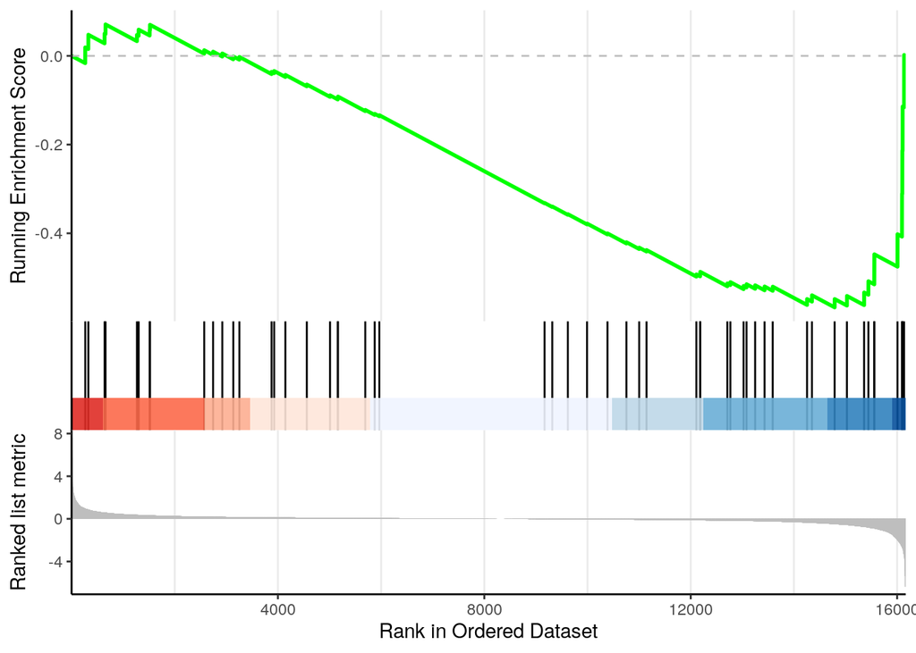

KO1_vs_CTL: GOBP_STEROL_HOMEOSTASIS

```r
print(KO1_vs_CTL_STEROL_gseaplots$GOBP_STEROL_HOMEOSTASIS)
```

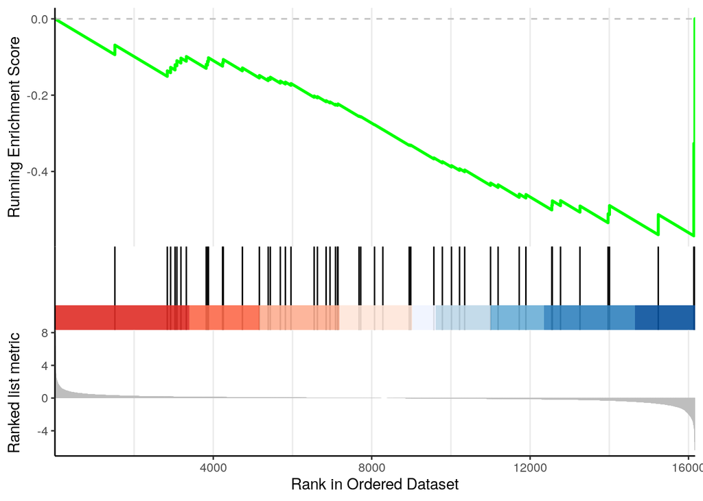

KO1_vs_CTL: GOBP_REGULATION_OF_CHOLESTEROL_METABOLIC_PROCESS

```r
print(KO1_vs_CTL_STEROL_gseaplots$GOBP_REGULATION_OF_CHOLESTEROL_METABOLIC_PROCESS)
```

## KO2_vs_CTL

Lipid genesets:

```r
DT::datatable(dplyr::select(KO2_vs_CTL_gsea_LIPIDS_results_df$LIPID, c("ID", "enrichmentScore", "NES", "pvalue", "p.adjust")) %>% dplyr::arrange(., pvalue),
              rownames = FALSE,
              options = list(pageLength = 10),
              caption = 'Table 1: KO2_vs_CTL - LIPIDS GSEA results.') %>%
  DT::formatRound(c('enrichmentScore', 'NES'), 2) %>%
  DT::formatRound(c('pvalue', 'p.adjust'), 4)
```

| ID | enrichmentScore | NES | pvalue | p.adjust |
| --- | --- | --- | --- | --- |
| GOBP_REGULATION_OF_LIPID_METABOLIC_PROCESS | -0.445414828207474 | -1.41984701126625 | 0.00284642541924095 | 0.150169204737733 |
| GOBP_REGULATION_OF_LIPID_BIOSYNTHETIC_PROCESS | -0.497566670147832 | -1.499859803049 | 0.00423011844331641 | 0.150169204737733 |
| GOBP_POSITIVE_REGULATION_OF_LIPID_METABOLIC_PROCESS | -0.523854084764325 | -1.51616615714465 | 0.00682824724636571 | 0.161601851497322 |
| GOBP_NEUTRAL_LIPID_BIOSYNTHETIC_PROCESS | -0.62350132568904 | -1.57234663533884 | 0.0119700531035083 | 0.212468442587273 |
| GOBP_NEUTRAL_LIPID_METABOLIC_PROCESS | -0.5065936990759 | -1.45206750824717 | 0.0179881198347107 | 0.255431301652893 |
| GOBP_POSITIVE_REGULATION_OF_LIPID_BIOSYNTHETIC_PROCESS | -0.540102310617383 | -1.46039830410861 | 0.0270514594091139 | 0.26372758290334 |
| GOBP_POSITIVE_REGULATION_OF_LIPID_LOCALIZATION | -0.522209135581419 | -1.4420427520484 | 0.0281423116226537 | 0.26372758290334 |
| GOBP_INTESTINAL_LIPID_ABSORPTION | -0.781104092868194 | -1.52973995715649 | 0.0297157839891087 | 0.26372758290334 |
| GOBP_REGULATION_OF_LIPID_LOCALIZATION | -0.473111465590885 | -1.37980715644579 | 0.0338543970277887 | 0.267073576552555 |
| GOBP_NEUTRAL_LIPID_CATABOLIC_PROCESS | -0.599495216676023 | -1.46133957369404 | 0.0432187662385866 | 0.276545682898523 |

[output cut: 61 more lines]

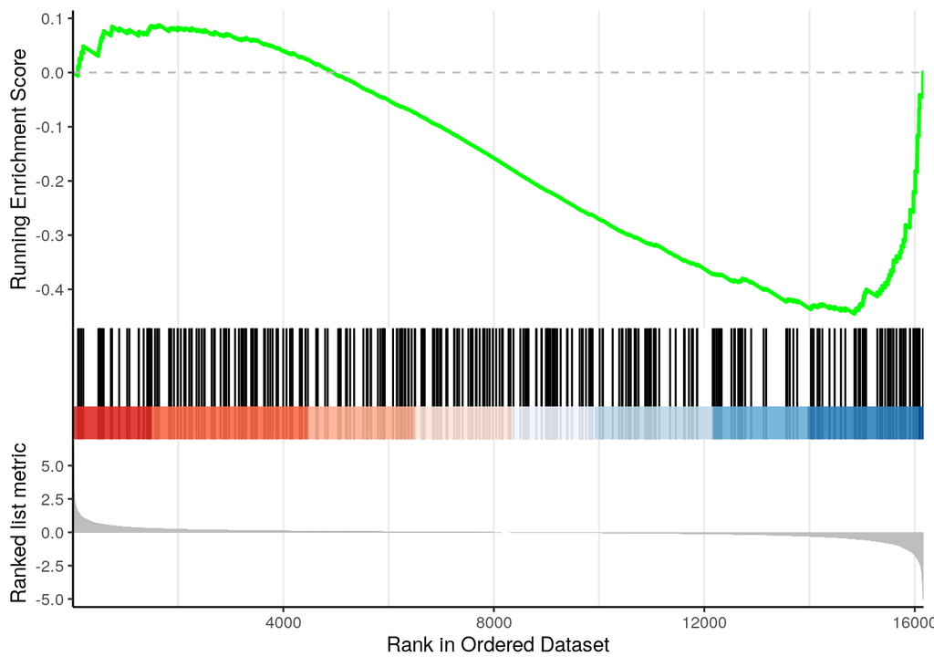

KO2_vs_CTL: GOBP_REGULATION_OF_LIPID_METABOLIC_PROCESS

```r
print(KO2_vs_CTL_LIPID_gseaplots$GOBP_REGULATION_OF_LIPID_METABOLIC_PROCESS)
```

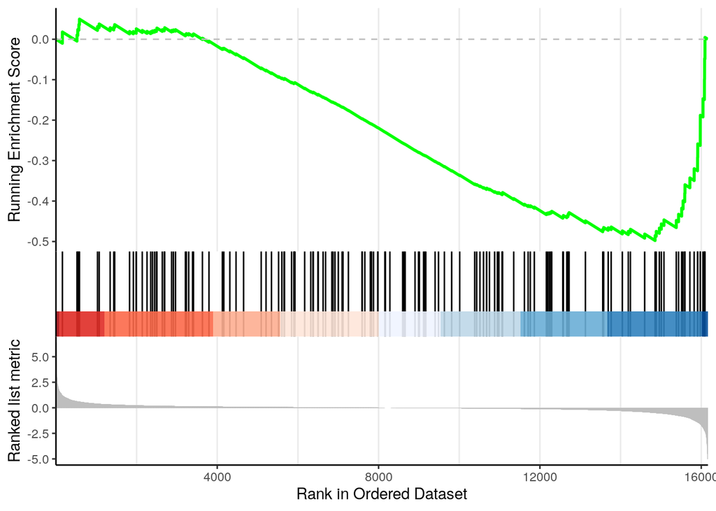

KO2_vs_CTL: GOBP_REGULATION_OF_LIPID_BIOSYNTHETIC_PROCESS

```r
print(KO2_vs_CTL_LIPID_gseaplots$GOBP_REGULATION_OF_LIPID_BIOSYNTHETIC_PROCESS)
```

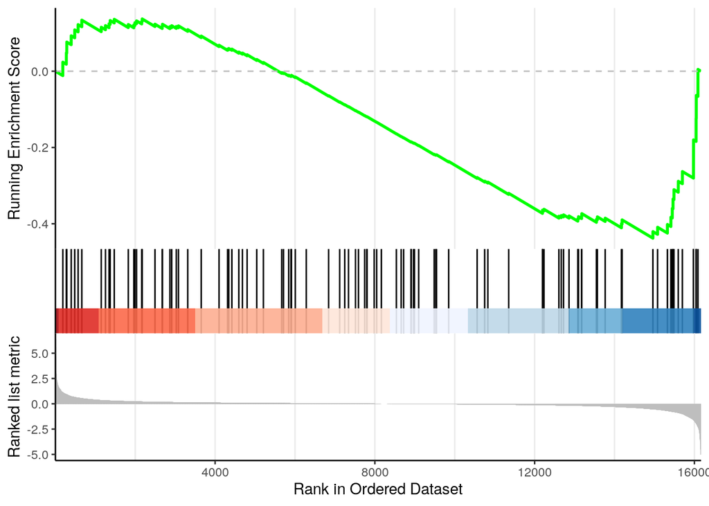

KO2_vs_CTL: GOBP_LIPID_HOMEOSTASIS

```r
print(KO2_vs_CTL_LIPID_gseaplots$GOBP_LIPID_HOMEOSTASIS)
```

Sterol genesets:

```r
DT::datatable(dplyr::select(KO2_vs_CTL_gsea_LIPIDS_results_df$STEROL, c("ID", "enrichmentScore", "NES", "pvalue", "p.adjust")) %>% dplyr::arrange(., pvalue),
              rownames = FALSE,
              options = list(pageLength = 10),
              caption = 'Table 1: KO2_vs_CTL - STEROLS GSEA results.') %>%
  DT::formatRound(c('enrichmentScore', 'NES'), 2) %>%
  DT::formatRound(c('pvalue', 'p.adjust'), 4)
```

| ID | enrichmentScore | NES | pvalue | p.adjust |
| --- | --- | --- | --- | --- |
| GOBP_STEROL_HOMEOSTASIS | -0.540621381324328 | -1.43325099664246 | 0.039097492569802 | 0.555238234395547 |
| GOBP_STEROL_TRANSPORT | -0.484963235539999 | -1.35438443970004 | 0.0584461299363734 | 0.555238234395547 |
| GOBP_REVERSE_CHOLESTEROL_TRANSPORT | -0.676104948188277 | -1.34884530464389 | 0.131825363825364 | 0.714893793480276 |
| GOBP_POSITIVE_REGULATION_OF_STEROL_TRANSPORT | -0.575133060675832 | -1.29925235209737 | 0.150612741276622 | 0.714893793480276 |
| GOBP_REGULATION_OF_CHOLESTEROL_METABOLIC_PROCESS | -0.450038015058301 | -1.17980895614611 | 0.223890265885534 | 0.714893793480276 |
| GOBP_REGULATION_OF_STEROL_TRANSPORT | -0.478509231943207 | -1.19107288251855 | 0.225755934783245 | 0.714893793480276 |
| GOBP_CHOLESTEROL_EFFLUX | -0.466850253070682 | -1.15649955821925 | 0.266194019992074 | 0.722526625692771 |
| GOBP_STEROL_METABOLIC_PROCESS | -0.34685570629719 | -1.02755062079439 | 0.415093872600587 | 0.761057277175477 |
| GOBP_RESPONSE_TO_STEROL | -0.454679288471756 | -1.04489972412237 | 0.418579150579151 | 0.761057277175477 |
| GOBP_REGULATION_OF_CHOLESTEROL_EFFLUX | -0.433303705749479 | -0.987496964398376 | 0.494511117313238 | 0.761057277175477 |

[output cut: 9 more lines]

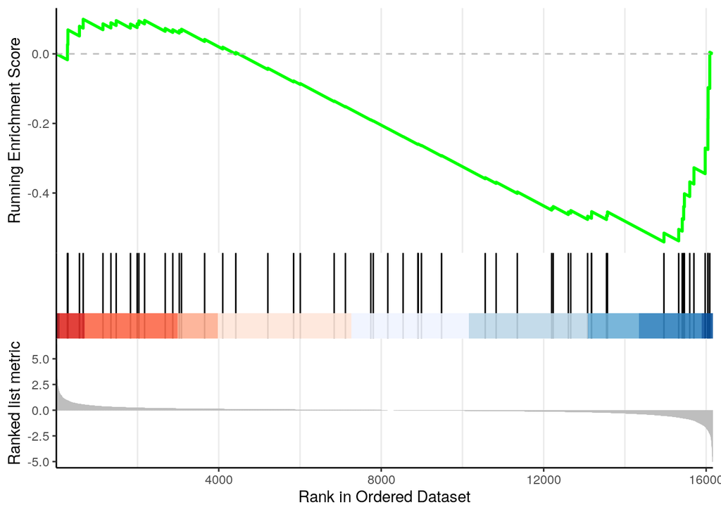

KO2_vs_CTL: GOBP_STEROL_HOMEOSTASIS

```r
print(KO2_vs_CTL_STEROL_gseaplots$GOBP_STEROL_HOMEOSTASIS)
```

```r
# saving session info
writeLines(capture.output(sessionInfo()), file.path(results_dir, "sessionInfo_them6_gsea.txt"))

renv::snapshot(lockfile = file.path(base_dir, "them6_gsea_renv.lock"))
```

```
## * Lockfile written to '~/workspace//them6_gsea_renv.lock'.
```

```r
renv::status(lockfile = file.path(base_dir, "them6_gsea_renv.lock"))
```

```
## * The project is already synchronized with the lockfile.
```

```r
# renv::diagnostics()
```